# RplotterPkg::create_scatter_plot() demos

Rick Dean

12/18/2019

```r
library(here)
library(ggplot2)
library(rlang)
library(ggrepel)
library(grid)
library(gtable)
library(dplyr)
library(readr)
library(modelr)
library(RplotterPkg)

here::here()
```

```
## [1] "F:/Code_R/plotting/RplotterPkg"
```

# Demos

## 1 Introduction

The following R scripts provides some scatter plot examples of [RplotterPkg::create_scatter_plot()](https://github.com/deandevl/RplotterPkg).

## 2 Setting the `aes_x` and `aes_y` aesthetics.

The *modelr::sim1* dataset has both a continuous independent variable `x` and continuous dependent variable `y`.

```r
str(modelr::sim1)
## tibble [30 x 2] (S3: tbl_df/tbl/data.frame)
##  $ x: int [1:30] 1 1 1 2 2 2 3 3 3 4 ...
##  $ y: num [1:30] 4.2 7.51 2.13 8.99 10.24 ...
```

Task: Set `aes_x` = “x” and `aes_y` = “y” from the *modelr::sim1* dataset and plot the points with axis’ defaults.

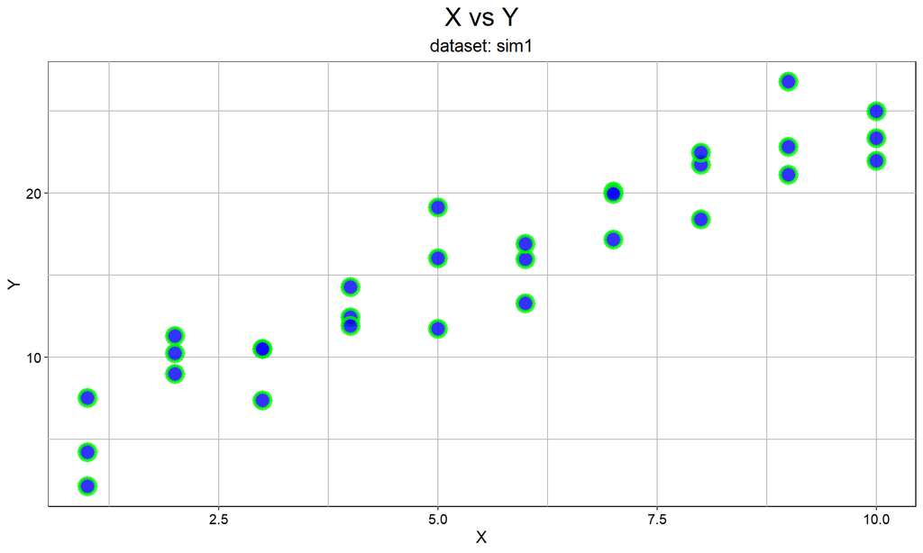

```r
RplotterPkg::create_scatter_plot(
  df = modelr::sim1,
  aes_x = "x",
  aes_y = "y",
  title = "X vs Y",
  center_titles = TRUE,
  subtitle = "dataset: sim1",
  x_title = "X",
  y_title = "Y",
  rot_y_tic_label = TRUE,
  pts_color = "green",
  pts_fill = "blue",
  pts_size = 5.0,
  pts_stroke = 2.0,
  pts_line_alpha = 0.8
)
```

Task: Define a linear model for the *modelr::sim1* dataset.

```r
model_indep_sim1 <- lm(y ~ x, data = modelr::sim1)
summary(model_indep_sim1)
##
## Call:
## lm(formula = y ~ x, data = modelr::sim1)
##
## Residuals:
##     Min      1Q  Median      3Q     Max
## -4.1469 -1.5197  0.1331  1.4670  4.6516
##
## Coefficients:
##             Estimate Std. Error t value Pr(>|t|)
## (Intercept)   4.2208     0.8688   4.858 4.09e-05 ***
## x             2.0515     0.1400  14.651 1.17e-14 ***
## ---
## Signif. codes:  0 '***' 0.001 '**' 0.01 '*' 0.05 '.' 0.1 ' ' 1
##
## Residual standard error: 2.203 on 28 degrees of freedom
## Multiple R-squared:  0.8846, Adjusted R-squared:  0.8805
## F-statistic: 214.7 on 1 and 28 DF,  p-value: 1.173e-14
```

Task: Compute the predictions from the linear model.

```r
sim1_pred_df <- modelr::add_predictions(data = modelr::sim1, model = model_indep_sim1)
str(sim1_pred_df)
## tibble [30 x 3] (S3: tbl_df/tbl/data.frame)
##  $ x   : int [1:30] 1 1 1 2 2 2 3 3 3 4 ...
##  $ y   : num [1:30] 4.2 7.51 2.13 8.99 10.24 ...
##  $ pred: Named num [1:30] 6.27 6.27 6.27 8.32 8.32 ...
##   ..- attr(*, "names")= chr [1:30] "1" "2" "3" "4" ...
```

Task: Plot the x/y points and their predictions from the model by setting `df` = `sim1_pred_df`, aesthetic variables `aes_x` = “x”, `aes_y` = “y”. Add a *geom_line* that plots the predicted line with `aes(y = pred)`.

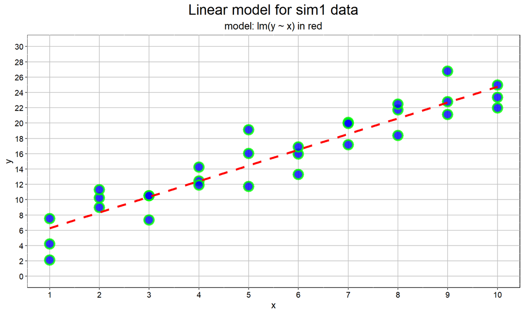

```r
RplotterPkg::create_scatter_plot(
  df = sim1_pred_df,
  aes_x = "x",
  aes_y = "y",
  title = "Linear model for sim1 data",
  subtitle = "model: lm(y ~ x) in red",
  center_titles = TRUE,
  rot_y_tic_label = TRUE,
  x_limits = c(1,10),
  x_major_breaks = seq(from = 0, to = 10, by = 1),
  y_limits = c(0,30),
  y_major_breaks = seq(from = 0, to = 30, by = 2),
  show_minor_grids = FALSE,
  pts_color = "green",
  pts_fill = "blue",
  pts_size = 5.0,
  pts_stroke = 2.0,
  pts_line_alpha = 0.8
) + geom_line(aes(y = pred), linetype = "dashed", color = "red", size = 1.5)
```

Task: Compute residuals of the linear model `lm(y ~ x)` for the *modelr::sim1* dataset.

```r
model_indep_sim1 <- lm(y ~ x, data = modelr::sim1)
residuals_sim1_df <- sim1 %>%
  modelr::add_residuals(model_indep_sim1, var = "Residual")
str(residuals_sim1_df)
## tibble [30 x 3] (S3: tbl_df/tbl/data.frame)
##  $ x       : int [1:30] 1 1 1 2 2 2 3 3 3 4 ...
##  $ y       : num [1:30] 4.2 7.51 2.13 8.99 10.24 ...
##  $ Residual: Named num [1:30] -2.072 1.238 -4.147 0.665 1.919 ...
##   ..- attr(*, "names")= chr [1:30] "1" "2" "3" "4" ...
```

Task: Plot the residuals by setting `df` = `residuals_sim1_df`, `aes_x` = “x”, and `aes_y` = “Residual”.

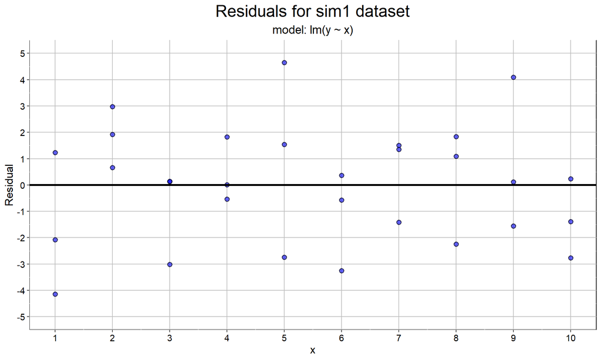

```r
RplotterPkg::create_scatter_plot(
  df = residuals_sim1_df,
  aes_x = "x",
  aes_y = "Residual",
  title = "Residuals for sim1 dataset",
  subtitle = "model: lm(y ~ x)",
  center_titles = TRUE,
  rot_y_tic_label = TRUE,
  x_limits = c(1,10),
  x_major_breaks = seq(from = 1, to = 10, by = 1),
  y_limits = c(-5,5),
  y_major_breaks = seq(from = -5, to = 5, by = 1),
  show_minor_grids = FALSE,
  pts_fill = "blue",
  pts_size = 2,
  pts_line_alpha = 0.6,
  bold_y = 0.0
)
```

## 3 Setting the `aes_x`, `aes_y`, and `aes_fill` aesthetics.

The *modelr::sim3* dataset has a continuous independent variable `x1`, a categorical independent variable `x2` and a continuous dependent variable `y`.

```r
str(modelr::sim3)
## tibble [120 x 5] (S3: tbl_df/tbl/data.frame)
##  $ x1 : int [1:120] 1 1 1 1 1 1 1 1 1 1 ...
##  $ x2 : Factor w/ 4 levels "a","b","c","d": 1 1 1 2 2 2 3 3 3 4 ...
##  $ rep: int [1:120] 1 2 3 1 2 3 1 2 3 1 ...
##  $ y  : Named num [1:120] -0.571 1.184 2.237 7.437 8.518 ...
##   ..- attr(*, "names")= chr [1:120] "a" "a" "a" "b" ...
##  $ sd : num [1:120] 2 2 2 2 2 2 2 2 2 2 ...
```

`x1` and `x2` are independent variables where `x2` is a factor variable with 4 levels.

Task: Define a linear model for the *modelr::sim3* dataset involving `x1` and `x2` as independent variables.

```r
model_indep_sim3 <- lm(y ~ x1 + x2, data = modelr::sim3)
summary(model_indep_sim3)
##
## Call:
## lm(formula = y ~ x1 + x2, data = modelr::sim3)
##
## Residuals:
##     Min      1Q  Median      3Q     Max
## -4.4674 -0.8524 -0.0729  0.7886  4.3005
##
## Coefficients:
##             Estimate Std. Error t value Pr(>|t|)
## (Intercept)  1.87167    0.38738   4.832 4.22e-06 ***
## x1          -0.19674    0.04871  -4.039 9.72e-05 ***
## x2b          2.88781    0.39571   7.298 4.07e-11 ***
## x2c          4.80574    0.39571  12.145  < 2e-16 ***
## x2d          2.35959    0.39571   5.963 2.79e-08 ***
## ---
## Signif. codes:  0 '***' 0.001 '**' 0.01 '*' 0.05 '.' 0.1 ' ' 1
##
## Residual standard error: 1.533 on 115 degrees of freedom
## Multiple R-squared:  0.5911, Adjusted R-squared:  0.5768
## F-statistic: 41.55 on 4 and 115 DF,  p-value: < 2.2e-16
```

Task: Compute residuals of the linear model `model_indep_sim3`.

```r
residuals_sim3_df <- modelr::sim3 %>%
  modelr::add_residuals(model_indep_sim3, var = "Residual")
str(residuals_sim3_df)
## tibble [120 x 6] (S3: tbl_df/tbl/data.frame)
##  $ x1      : int [1:120] 1 1 1 1 1 1 1 1 1 1 ...
##  $ x2      : Factor w/ 4 levels "a","b","c","d": 1 1 1 2 2 2 3 3 3 4 ...
##  $ rep     : int [1:120] 1 2 3 1 2 3 1 2 3 1 ...
##  $ y       : Named num [1:120] -0.571 1.184 2.237 7.437 8.518 ...
##   ..- attr(*, "names")= chr [1:120] "a" "a" "a" "b" ...
##  $ sd      : num [1:120] 2 2 2 2 2 2 2 2 2 2 ...
##  $ Residual: Named num [1:120] -2.246 -0.491 0.562 2.874 3.956 ...
##   ..- attr(*, "names")= chr [1:120] "a" "a" "a" "b" ...
```

Task: Plot `x1` vs residuals across levels of `x2` by setting `df` = `residuals_sim3_df`, `aes_x` = “x1”, `aes_y` = “Residual” and `aes_fill` = “x2”.

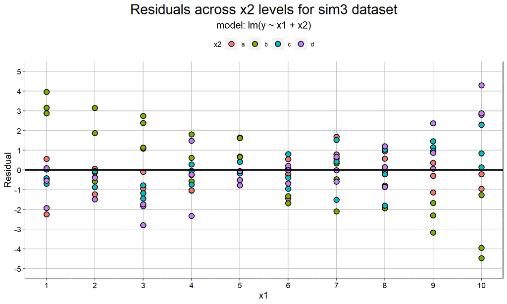

```r
RplotterPkg::create_scatter_plot(
  df = residuals_sim3_df,
  aes_x = "x1",
  aes_y = "Residual",
  aes_fill = "x2",
  title = "Residuals across x2 levels for sim3 dataset",
  subtitle = "model: lm(y ~ x1 + x2)",
  center_titles = TRUE,
  rot_y_tic_label = TRUE,
  x_limits = c(1,10),
  x_major_breaks = seq(from = 1, to = 10, by = 1),
  y_limits = c(-5,5),
  y_major_breaks = seq(from = -5, to = 5, by = 1),
  show_minor_grids = FALSE,
  pts_size = 3,
  bold_y = 0.0
)
```

## 4 Setting the `aes_x` and `aes_y` aesthetics across factor levels.

Task: Repeat the above residuals plot from the *modelr::sim3* dataset but put `x1` vs `Residual` in separate plots/panels across levels of `x2`. Remove the `aes_fill` assignment and set `factor_var` to “x2”. Put each plot of `x1` vs `Residual` in separate panels/levels of `x2` on one row (set columns = 4) using `RplotterPkg::multi_scatter_plot()`.

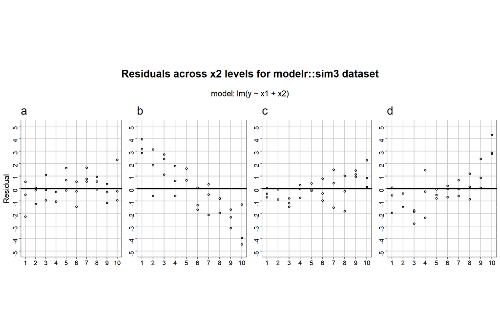

```r
plot_sim3_panels_resid <- RplotterPkg::multi_scatter_plot(
  df = residuals_sim3_df,
  factor_var = "x2",
  factor_x = "x1",
  columns = 4,
  aes_y = "Residual",
  title = "Residuals across x2 levels for modelr::sim3 dataset",
  subtitle = "model: lm(y ~ x1 + x2)",
  x_limits = c(1,10),
  x_major_breaks = seq(from = 1, to = 10, by = 1),
  y_limits = c(-5,5),
  y_major_breaks = seq(from = -5, to = 5, by = 1),
  show_minor_grids = FALSE,
  bold_y = 0.0,
  col_width = 3
)
```

Task: Define a linear independent and interactive model for the *modelr::sim3* dataset.

```r
model_indep_sim3 <- lm(y ~ x1 + x2, data = modelr::sim3)
model_inter_sim3 <- lm(y ~ x1 * x2, data = modelr::sim3)
```

Task: Compute the residuals of both models from *modelr::sim3* by using `modelr::gather_residuals()`

```r
residuals_models_sim3_df <- modelr::sim3 %>%
  modelr::gather_residuals(model_indep_sim3, model_inter_sim3, .resid = "Residual", .model = "Model")
str(residuals_models_sim3_df)
## tibble [240 x 7] (S3: tbl_df/tbl/data.frame)
##  $ Model   : chr [1:240] "model_indep_sim3" "model_indep_sim3" "model_indep_sim3" "model_indep_sim3" ...
##  $ x1      : int [1:240] 1 1 1 1 1 1 1 1 1 1 ...
##  $ x2      : Factor w/ 4 levels "a","b","c","d": 1 1 1 2 2 2 3 3 3 4 ...
##  $ rep     : int [1:240] 1 2 3 1 2 3 1 2 3 1 ...
##  $ y       : Named num [1:240] -0.571 1.184 2.237 7.437 8.518 ...
##   ..- attr(*, "names")= chr [1:240] "a" "a" "a" "b" ...
##  $ sd      : num [1:240] 2 2 2 2 2 2 2 2 2 2 ...
##  $ Residual: Named num [1:240] -2.246 -0.491 0.562 2.874 3.956 ...
##   ..- attr(*, "names")= chr [1:240] "a" "a" "a" "b" ...
```

Task: Plot the residuals from each model by setting `df` = `residuals_models_sim3_df`, `factor_x` = “y”, `aes_y` = “Residual”, `factor_var` = “Model” for a separate panel display for each model level.

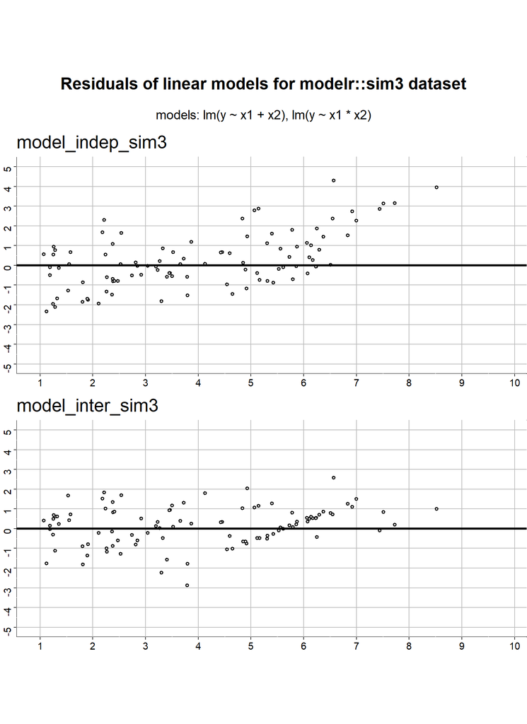

```r
plot_sim3_indep_inter <- multi_scatter_plot(
  df = residuals_models_sim3_df,
  factor_var = "Model",
  factor_x = "y",
  columns = 1,
  aes_y = "Residual",
  title = "Residuals of linear models for modelr::sim3 dataset",
  subtitle = "models: lm(y ~ x1 + x2), lm(y ~ x1 * x2)",
  x_limits = c(1,10),
  x_major_breaks = seq(from = 1, to = 10, by = 1),
  y_limits = c(-5,5),
  y_major_breaks = seq(from = -5, to = 5, by = 1),
  show_minor_grids = FALSE,
  bold_y = 0.0,
  col_width = 8.5
)
```

Task: From the *ggplot2::mpg* plot `cty` vs `hwy` across levels of car compacts using `RplotterPkg::multi_scatter_plot()` with the plots under a single column (i.e. columns = 1). Label the points with the model name.

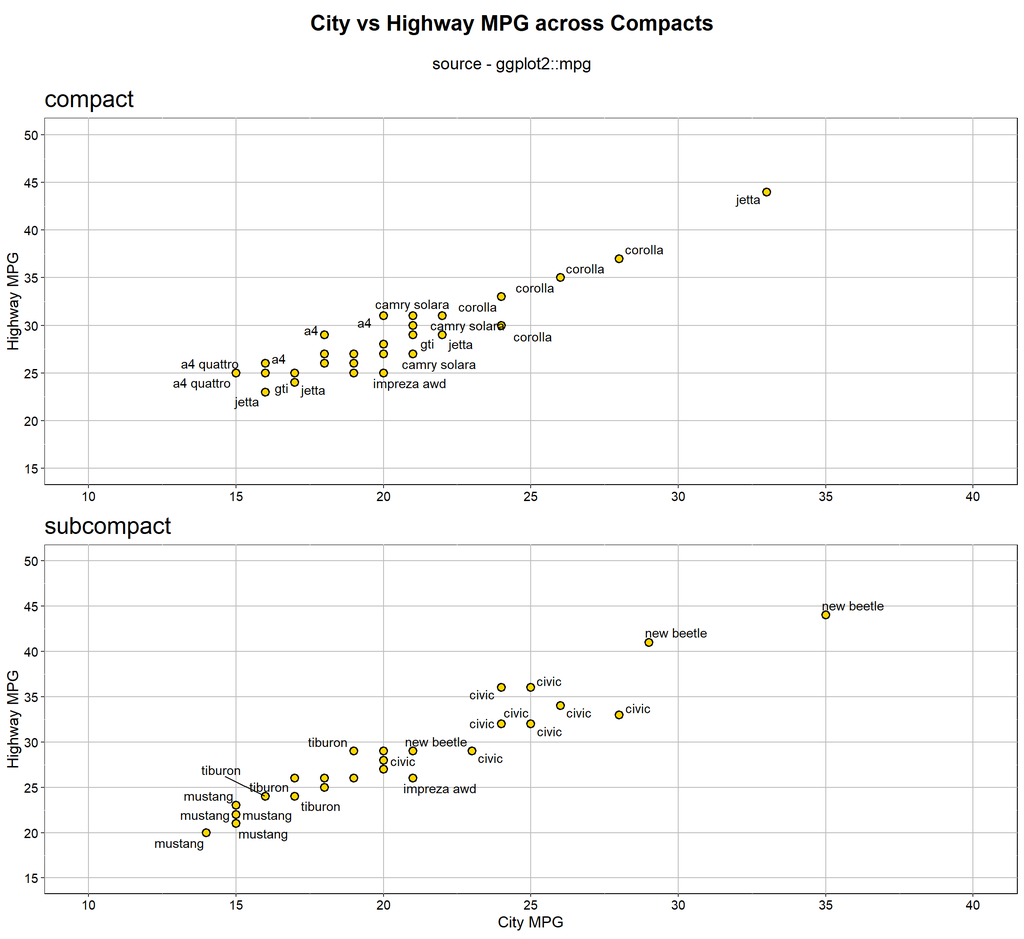

```r
compact_df <- ggplot2::mpg %>%
  dplyr::filter(class == "compact" | class == "subcompact")
plot_mtcars <- RplotterPkg::multi_scatter_plot(
  df = compact_df,
  factor_var = "class",
  factor_x = "cty",
  columns = 1,
  aes_y = "hwy",
  aes_label = "model",
  x_limits = c(10,40),
  x_major_breaks = seq(10,40,5),
  y_limits = c(15,50),
  y_major_breaks = seq(15,50,5),
  title = "City vs Highway MPG across Compacts",
  subtitle = "source - ggplot2::mpg",
  x_title = "City MPG",
  y_titles = c("Highway MPG", "Highway MPG"),
  rot_y_tic_label = TRUE,
  pts_size = 2.5,
  pts_fill = "gold",
  show_minor_grids = FALSE,
  row_height = 5,
  col_width = 12
)
```

Task: Plot the *gapminder* dataset of `lifeExp` vs `pop` across `continent` and `year` using `RplotterPkg::multi_scatter_plot()`.

```r
gapminder_df <- gapminder::gapminder %>%
  filter(year > 1987 & continent %in% c("Africa", "Americas", "Asia", "Europe")) %>%
  droplevels() %>%
  mutate(year = factor(year)) %>%
  mutate(pop = pop/1e+6) %>%
  rename(
    Year = year,
    Population = pop,
    Life_Exp = lifeExp,
    Continent = continent
  )
str(gapminder_df)
## tibble [560 x 6] (S3: tbl_df/tbl/data.frame)
##  $ country   : Factor w/ 140 levels "Afghanistan",..: 1 1 1 1 2 2 2 2 3 3 ...
##  $ Continent : Factor w/ 4 levels "Africa","Americas",..: 3 3 3 3 4 4 4 4 1 1 ...
##  $ Year      : Factor w/ 4 levels "1992","1997",..: 1 2 3 4 1 2 3 4 1 2 ...
##  $ Life_Exp  : num [1:560] 41.7 41.8 42.1 43.8 71.6 ...
##  $ Population: num [1:560] 16.32 22.23 25.27 31.89 3.33 ...
##  $ gdpPercap : num [1:560] 649 635 727 975 2497 ...
```

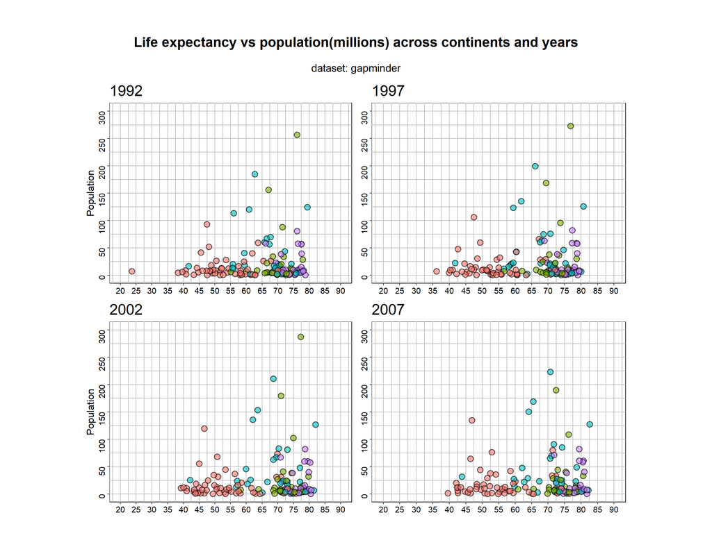

```r
gapminder_plot <- RplotterPkg::multi_scatter_plot(
  df = gapminder_df,
  factor_var = "Year",
  factor_x = "Life_Exp",
  aes_y = "Population",
  aes_fill = "Continent",
  x_limits = c(20,90),
  x_major_breaks = seq(from = 20, to = 90, by = 5),
  y_limits = c(0,300),
  y_major_breaks = seq(from = 0, to = 300, by = 50),
  title = "Life expectancy vs population(millions) across continents and years",
  subtitle = "dataset: gapminder",
  pts_size = 3,
  pts_line_alpha = 0.6,
  col_width = 5
)
```

```r
str(ggplot2::economics)
## tibble [574 x 6] (S3: spec_tbl_df/tbl_df/tbl/data.frame)
##  $ date    : Date[1:574], format: "1967-07-01" "1967-08-01" ...
##  $ pce     : num [1:574] 507 510 516 512 517 ...
##  $ pop     : num [1:574] 198712 198911 199113 199311 199498 ...
##  $ psavert : num [1:574] 12.6 12.6 11.9 12.9 12.8 11.8 11.7 12.3 11.7 12.3 ...
##  $ uempmed : num [1:574] 4.5 4.7 4.6 4.9 4.7 4.8 5.1 4.5 4.1 4.6 ...
##  $ unemploy: num [1:574] 2944 2945 2958 3143 3066 ...
```

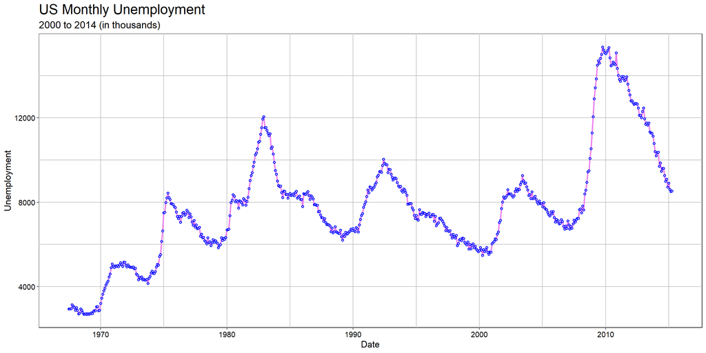

```r
RplotterPkg::create_scatter_plot(
  df = ggplot2::economics,
  aes_x = "date",
  aes_y = "unemploy",
  x_title = "Date",
  y_title = "Unemployment",
  rot_y_tic_label = TRUE,
  title = "US Monthly Unemployment",
  subtitle = "2000 to 2014 (in thousands)",
  pts_color = "blue",
  line_color = "violet",
  connect = TRUE
)
```

Task: Repeat the above plot with values for `x_date_labels`, and `x_major_date_breaks` in a Year-month format. Do not draw the point symbols.

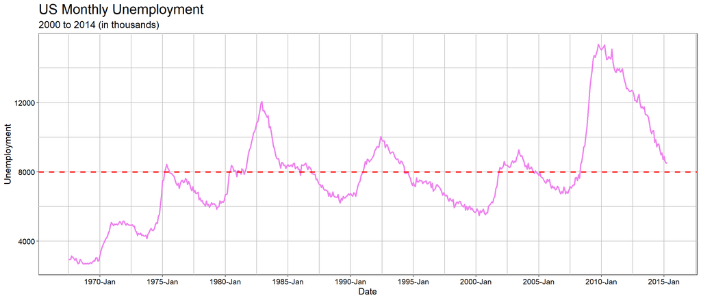

```r
RplotterPkg::create_scatter_plot(
  df = ggplot2::economics,
  aes_x = "date",
  aes_y = "unemploy",
  x_title = "Date",
  y_title = "Unemployment",
  rot_y_tic_label = TRUE,
  title = "US Monthly Unemployment",
  subtitle = "2000 to 2014 (in thousands)",
  line_color = "violet",
  show_pts = FALSE,
  connect = TRUE,
  x_date_labels = "%Y-%b",
  x_major_date_breaks = "5 year"
) + geom_hline(aes(yintercept = 8000), color = "red", linetype = "dashed", lwd = 1)
```

Task: Repeat the above plot and set the x axis breaks as a sequence of years.

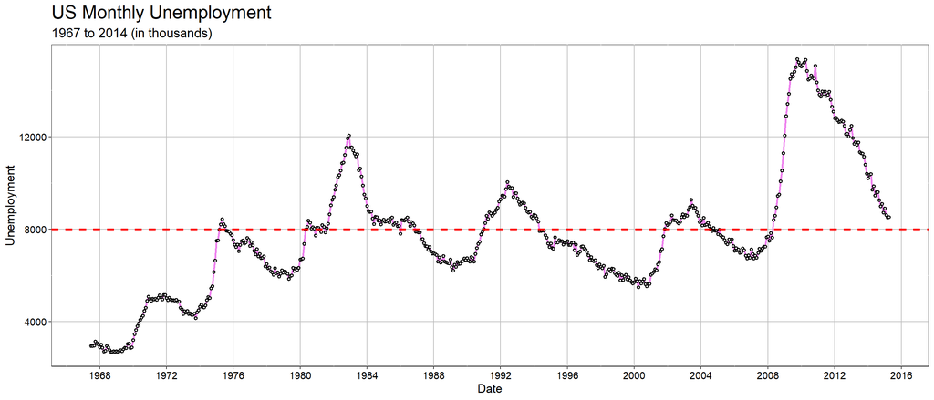

```r
RplotterPkg::create_scatter_plot(
  df = ggplot2::economics,
  aes_x = "date",
  aes_y = "unemploy",
  x_title = "Date",
  y_title = "Unemployment",
  rot_y_tic_label = TRUE,
  title = "US Monthly Unemployment",
  subtitle = "1967 to 2014 (in thousands)",
  line_color = "violet",
  connect = TRUE,
  x_date_labels = "%Y",
  x_major_breaks = seq.Date(from = as.Date("1964-01-01"), to = as.Date("2020-01-01"), by = "4 year"),
  show_minor_grids = FALSE
) + geom_hline(aes(yintercept = 8000), color = "red", linetype = "dashed", lwd = 1)
```

Task: Read the *yosemite_temps.csv* file.

```r
yosemite_df <- readr::read_csv("../data/yosemite_temp.csv")
str(yosemite_df)
## tibble [121 x 2] (S3: spec_tbl_df/tbl_df/tbl/data.frame)
##  $ time: chr [1:121] "2017-05-01 0:00" "2017-05-01 0:05" "2017-05-01 0:10" "2017-05-01 0:15" ...
##  $ y   : num [1:121] 27.8 27 26.8 26.5 25.6 25 24.9 24.1 23.7 23.2 ...
##  - attr(*, "spec")=
##   .. cols(
##   ..   time = col_character(),
##   ..   y = col_double()
##   .. )
```

Convert `yosemite_df` time as POSIXct.

```r
yosemite_df <- yosemite_df %>%
  mutate(time_alt = as.POSIXct(time, format = "%Y-%m-%d %H:%M"))
str(yosemite_df)
## tibble [121 x 3] (S3: spec_tbl_df/tbl_df/tbl/data.frame)
##  $ time    : chr [1:121] "2017-05-01 0:00" "2017-05-01 0:05" "2017-05-01 0:10" "2017-05-01 0:15" ...
##  $ y       : num [1:121] 27.8 27 26.8 26.5 25.6 25 24.9 24.1 23.7 23.2 ...
##  $ time_alt: POSIXct[1:121], format: "2017-05-01 00:00:00" "2017-05-01 00:05:00" ...
##  - attr(*, "spec")=
##   .. cols(
##   ..   time = col_character(),
##   ..   y = col_double()
##   .. )
```

Task: Plot the datetime data of Yosemite temperatures recorded every 5 minutes.

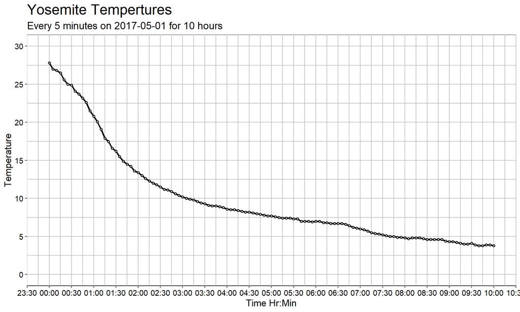

```r
RplotterPkg::create_scatter_plot(
  df = yosemite_df,
  title = "Yosemite Tempertures",
  subtitle = "Every 5 minutes on 2017-05-01 for 10 hours",
  x_title = "Time Hr:Min",
  y_title = "Temperature",
  rot_y_tic_label = TRUE,
  aes_x = "time_alt",
  aes_y = "y",
  y_limits = c(0,30),
  y_major_breaks = seq(from = 0, to = 30, by = 5),
  x_date_labels = "%H:%M",
  x_major_date_breaks = "30 min",
  connect = TRUE
)
```